# Detailed Analysis of VaR using GARCH(1,1)

Renaud Dupont, Bilal Oukal

2024-03-03

## Introduction

This document provides a detailed explanation of the R script used to find the VaR of financial data using GARCH.

### Loading Libraries and Source Files

The script starts by loading necessary libraries:

- `here`: Simplifies the path specification by using the project’s root directory as a reference point.
- `xts`: Provides an extensible time series class, allowing for easy manipulation of time series data.
- `PerformanceAnalytics`: Offers tools for performance and risk analysis of financial instruments.

Additionally, it sources additional R scripts containing custom functions essential for the analysis:

- `f_forecast_var.R`: Contains the function for forecasting VaR.
- `f_uGarch_lib.R`: Contains functions related to testing GARCH.

```r
library("here")
library("xts")
library("PerformanceAnalytics")
source(here("Code/f_forecast_var.R"))
source(here("Code/f_uGarch_lib.R"))
```

### Data Loading and Filtering

The script loads stock index price data from an `.rda` file and filters this data to include records starting from January 1, 2005. It also sets a confidence level of 95% for the VaR computation, indicating the level of confidence in the risk estimate.

```r
index_prices = get(load(here("Data/indices.rda")))
start_analysis_date <- "2005-01-01/"
index_prices = index_prices[start_analysis_date,]
level = 0.95
```

### Setting Plot Parameters

We adjust the plotting parameters to ensure that the visualizations are displayed as intended. This includes specifying the number of charts to be displayed in a single row and reducing the size of the labels.

```r
par(mfrow = c(1,1), # set 1 chart in 1 row
    cex = 0.6) # labels are now 60% of their normal size
```

### Log-Returns Calculation

The log-returns are calculated for the S&P 500 and FTSE 100 indices, as well as for all indices in the dataset. The number of bins for the histogram is also calculated based on the length of the log returns.

```r
log_returns_sp500 = CalculateReturns(index_prices$SP500, method = "log")[-1]
log_returns_fste100 = CalculateReturns(index_prices$FTSE100, method = "log")[-1]
log_returns = CalculateReturns(index_prices)[-1]

number_of_bins = round(10 *log(length(log_returns)))
```

### VaR Forecast Computation

#### 1) Compute the VaR and the Garch parameters forecast for the S&P 500 index

The `f_forecast_var` function is used to compute the Garch parameters forecast and the VaR forecast for the S&P 500 index. The function returns a list containing the Garch parameters forecast and the VaR forecast. The `level` parameter specifies the confidence level for the VaR forecast.

```r
VaR_forecast_sp500 = f_forecast_var(log_returns_sp500, level = level)
VaR_forecast_sp500$GARCH_param
```

```
## [1] 1.696115e-06 8.997050e-02 8.975595e-01
```

```r
VaR_forecast_sp500$VaR
```

```
## [1] -0.0166515
```

#### 2) Plot the conditional variance as a time series

The conditional variances are plotted as a time series for the S&P 500 index, and the objective function values are also plotted.

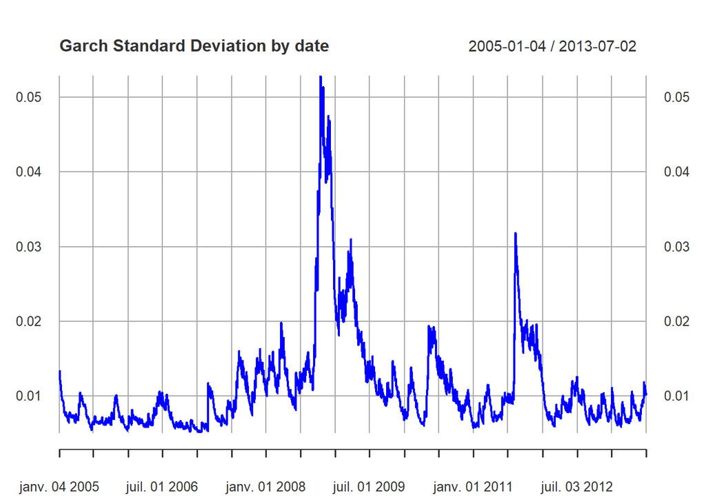

```r
dates_vector <- index(index_prices)
xts_conditional_variances <- xts(VaR_forecast_sp500$ConditionalVariances, order.by = as.Date(dates_vector)+1)

plot(sqrt(xts_conditional_variances), type="l",
     xlab = "Garch Standard Deviation",
     main="Garch Standard Deviation by date", col="blue")
```

#### 3) Plot the objective function values

The objective function values are plotted to show the convergence of the optimization algorithm used to estimate the Garch parameters.

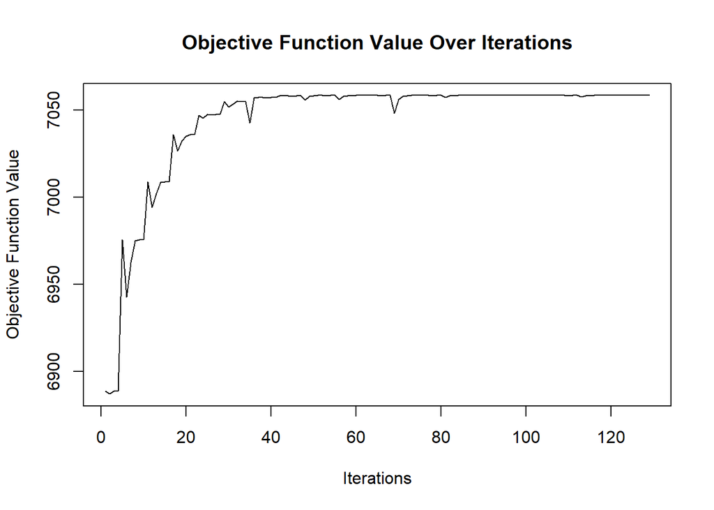

```r
plot(store$objective_values, type = 'l',
     xlab = "Iterations", ylab = "Objective Function Value",
     main = "Objective Function Value Over Iterations")
```

#### 4) Estimating the VaR and the parameters using rugarch

The `f_test_rugarch` function is used to estimate the VaR and the parameters using the `rugarch` package to use it as a benchmark our estimation. The function returns the VaR and the parameters of rugarch.

```r
rugarch_test = f_test_rugarch(log_returns_sp500,0.95)
```

```
## VaR and Params from rugarch:
## VaR: -0.01718807
## Parameters: 1.700554e-06 0.08983627 0.8976026
```

```r
cat("VaR and Params from implemented garch:\nVaR:", VaR_forecast_sp500$VaR, "\nParameters:",
    (VaR_forecast_sp500$GARCH_param), "\n")
```

```
## VaR and Params from implemented garch:
## VaR: -0.0166515
## Parameters: 1.696115e-06 0.0899705 0.8975595
```

#### 5) Plot the histogram of the log returns and the VaR forecast

The histogram of the log-returns for the S&P 500 index is plotted, and the VaR forecast from the implemented Garch model and the VaR from the `rugarch` package are added to the plot. The VaR from the data is also included for comparison.

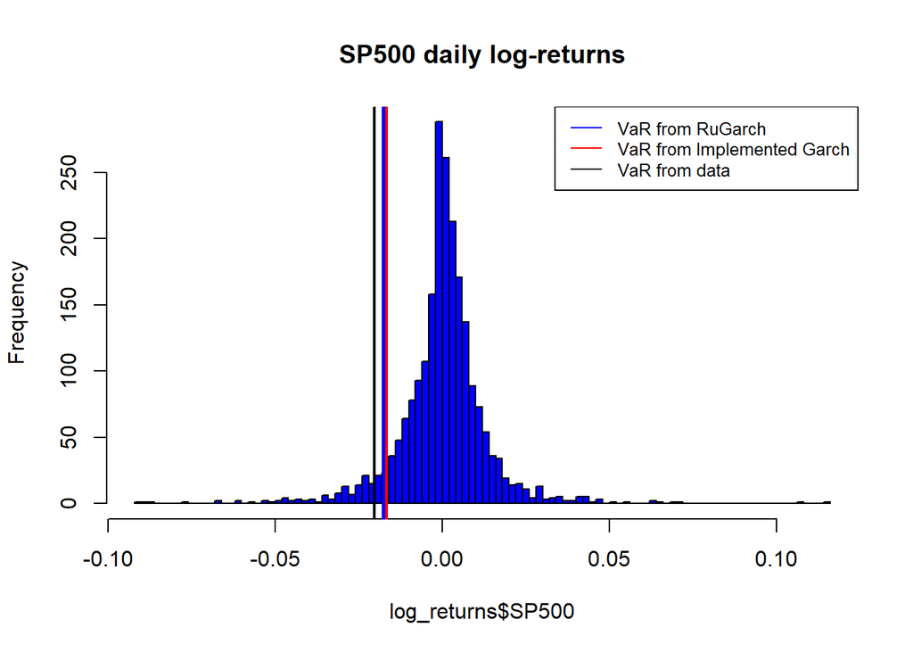

```r
hist(log_returns$SP500, main = "SP500 daily log-returns", col = "blue", breaks = 100)
abline(v=rugarch_test$VaR, col="blue", lwd = 4 )
abline(v=VaR_forecast_sp500$VaR_Forecast, col="red", lwd = 2 )
abline(v=quantile(log_returns$SP500,0.05), col = "black", lwd = 2 )
legend("topright", legend=c("VaR from RuGarch","VaR from Implemented Garch", "VaR from data"),
       col = c("blue","red", "black"), lty = 1:1, cex = 0.8)
```

#### 6) Show the result

The VaR forecast from the data, Garch, and Rugarch are printed for comparison.

```r
cat("VaR from data SP500", "\n", quantile(log_returns$SP500,0.05), "\n")
```

```
## VaR from data SP500
##  -0.02027768
```

```r
cat("Var from Garch", "\n", VaR_forecast_sp500$VaR_Forecast, "\n")
```

```
## Var from Garch
##  -0.0166515
```

```r
cat("VaR from Rugarch", "\n", rugarch_test$VaR, "\n")
```

```
## VaR from Rugarch
##  -0.01718807
```

As we can see from the results, the VaR forecast from the implemented Garch model is close to the VaR from the `rugarch` package, and both are close to the VaR from the data.

## Questions Answers

### 1) Use the first T = 1000 log-returns to estimate the VaR of each index at the 95% risk level. Which one is the most risky at the T + 1 horizon?

The VaR at 95% for the S&P 500 and FTSE 100 indices is calculated using the first 1000 log-returns. The most risky index at the T + 1 horizon is determined based on the VaR forecast.

```r
number_of_days = 1000
VaR_forecast_sp500 = f_forecast_var(log_returns_sp500[1:number_of_days], level = level)
cat("VaR at 95% for SP500:", VaR_forecast_sp500$VaR_Forecast, "\n")
```

```
## VaR at 95% for SP500: -0.07214194
```

```r
VaR_forecast_fste100 = f_forecast_var(log_returns_fste100[1:number_of_days], level = level)
cat("VaR at 95% for FSTE100:", VaR_forecast_fste100$VaR_Forecast, "\n")
```

```
## VaR at 95% for FSTE100: -0.06535982
```

```r
most_risky = ifelse(VaR_forecast_sp500$VaR_Forecast < VaR_forecast_fste100$VaR_Forecast, "SP500", "FSTE100")
cat("The most risky index is:", most_risky, "\n")
```

```
## The most risky index is: SP500
```

```r
# Compare the VaR forecast with the actual losses
f_test_rugarch(log_returns_sp500[1:number_of_days],level)
```

```
## VaR and Params from rugarch:
## VaR: -0.07553515
## Parameters: 1.097358e-06 0.08111888 0.9130136
```

[output not shown]

```r
f_test_rugarch(log_returns_fste100[1:number_of_days],level)
```

```
## VaR and Params from rugarch:
## VaR: -0.06944164
## Parameters: 1.288479e-06 0.1404679 0.8585194
```

[output not shown]

### 2) Using a rolling window of T = 1000 days, compute and store the next-step-ahead VaR at the 95% risk level for the next 1000 days. Display the series of realized returns and the VaR estimates for both series. Save in a `png` file. Save the results of the backtest in a `rda` file.

#### 1) Use the parallel package to parallelize the computation of the VaR forecast

A parallel cluster is created to parallelize the computation of the VaR forecast. A list of function are exported to the cluster to enable its use in parallel computations.

```r
window_size = 1000
number_of_windows = 1000
VaR_forecast_sp500 = rep(NA, number_of_windows)
VaR_forecast_fste100 = rep(NA, number_of_windows)

library("parallel")
library("Rsolnp")

cl <- makeCluster(detectCores() - 2) # Leave 2 cores free for system processes
clusterExport(cl, list("f_forecast_var", "log_returns_sp500",
                       "log_returns_fste100",
                       "window_size",
                       "level",
                       "solnp",
                       "f_ineq_constraint",
                       "f_nll",
                       "ComputeHtGarch","store"))
```

#### 2) Use parLapply to parallelize the computation of the VaR forecast

The `parLapply` function is used to parallelize the computation of the VaR forecast for both the S&P 500 and FTSE 100 indices using a rolling window of T = 1000 days.

```r
VaR_forecast_sp500 <- parLapply(cl, 1:number_of_windows, function(i) {
  cat("SP500 windows ",i)
  f_forecast_var(log_returns_sp500[i:(i+window_size-1)], level = 0.95)$VaR_Forecast
})
VaR_forecast_fste100 <- parLapply(cl, 1:number_of_windows, function(i) {
  cat("FSTE100 windows ",i)
  f_forecast_var(log_returns_fste100[i:(i+window_size-1)], level = 0.95)$VaR_Forecast
})
stopCluster(cl)
```

#### 3) Convert the list of VaR forecasts into a time series

```r
VaR_forecast_sp500_vector <- unlist(VaR_forecast_sp500)

dates <- index(log_returns_sp500)[window_size:(window_size + number_of_windows - 1)]
VaR_forecast_sp500_xts <- xts(VaR_forecast_sp500_vector, order.by = dates)
```

#### 4) Plot the VaR forecast and the log-returns and output the graph

The VaR forecast and the log-returns for the S&P 500 index are plotted, and the graph is saved as a `png` file in the folder created called `Outputs`.

```r
library("quantmod")

png(here("Outputs/VaR_forecast_sp500.png"), width = 1920, height =1080 )

plot.xts(VaR_forecast_sp500_xts, type = 'l', col = 'blue', xlab = "Window", ylab = "VaR Forecast",
     main = "VaR Forecast for S&P 500")

returns=log_returns_sp500[window_size:(window_size+number_of_windows-1)]
daysBelowVaR = sum(returns < VaR_forecast_sp500_vector)
percentageBelowVaR = daysBelowVaR/number_of_windows *100
cat("The percentage of time that the returns are below the VaR forecast is:", percentageBelowVaR, "%", "\n")
```

```
## The percentage of time that the returns are below the VaR forecast is: 4.3 %
```

```r
lines(returns, col = 'red')

addLegend("topright", on = 1, col = c("blue", "red"),
       legend.names = c("VaR Forecast", "Returns"),
       lty = 1, cex = 0.8,
       title= "Legend:", )
message = paste("The percentage of time that the returns are below the VaR forecast is:", percentageBelowVaR, "%")
mtext(message, side = 1, line = -2)
dev.off()
```

#### 5) Save the results of the backtest in a `rda` file

The results of the backtest are saved in an `.rda` file.

```r
backtest_results = data.frame(returns = returns, VaR_forecast = VaR_forecast_sp500_vector)
save(backtest_results, file = here("Outputs/backtest_results.rda"))
```